# Pràctica 2: Neteja i validació de les dades

Carlos Pérez Martín i Oscar Fernandez Castro

18 de mayo de 2019

### Descripció del dataset. Perquè és important i quina pregunta/problema pretén respondre?

Els datasets obtingut de https://www.kaggle.com, contenen informació sobre els passatgers del titanic. Des de dades demogràfiques dels passatgers fins a si van sobreviure o no al viatge.

En total hi han 3 datatsets:

- train: 12 atributs amb 891 files.
- test: 11 atributs amb 418 files.
- gender_submission: 2 atributs amb 418 files.

Els tres datasets formen un conjunt de prova i d’entrenament.

Els atributs que tenim en els diferents datasets són:

- Survival: Supervivent (0 = No, 1 = Si)
- Pclass: Classe del passatger (1= 1era, 2 = 2ona, 3 = 3ra)
- Name: Nom
- Sex: Sexe (female, male)
- Age: edad
- Sibsp: Nombre de familiars
- Parch: Nombre de pares/fills embarcats
- Ticket: Número d’entrada
- Fare: Tarifa
- Cabin: cabina
- Embarked: Embarcat (C = Cherbourg, Q = Queenstown, S = Southampton)

La pregunta que volem respondre, és quins són els factors més determinants que influeixen en la taxa de supervivència del passatge. Quins atributs tenen un impacte més elevat? (sexe, classe, edat, etc). Per això s’utilitzaran mètodes de regressió per avaluar les relacions entre atributs.

### Integració i selecció de les dades d’interès a analitzar.

Per començar unificarem els tres datasets en un per fer la neteja de les dades. Després en cas necessari ja se separaran de nou en conjunts de prova i d’entrenament.

```r
data_test<- read.csv('D:/Google Drive/Master Data Science/2018-19_2/Tipologia i cicle de vida de les dades/PRAC2. Neteja i validació de dades/titanic/test.csv',header=T,sep=",", encoding = "UTF-8")
data_sub<-read.csv('D:/Google Drive/Master Data Science/2018-19_2/Tipologia i cicle de vida de les dades/PRAC2. Neteja i validació de dades/titanic/gender_submission.csv',header=T,sep=",", encoding = "UTF-8")

#unifiquem el dataset de test amb els seus resultats
data_test <- merge(data_test,data_sub, by="PassengerId")

#juntem les files dels datasets de train i test
data<-rbind(data_train, data_test)
```

Ara ja tenim el dataset complet amb 1309 registres i 12 atributs.

Volem analitzar el nombre més gran d’atributs possibles, però a simple vista, ja podem dir que els atributs Name i PassangerId, no ens aporten informació, així que els eliminarem.

Agafarem l’atribut survived com a referència i utilitzant diferents mètodes estadístics, veurem quin impacte tenen els altres atributs sobre aquest.

### Neteja de les dades.

Al fer una revisió del tipus de dades, veiem que l’atribut Pclass és de tipus enter, quan hauria de ser de tipus factor. En el cas de l’atribut Survived també és de tipus enter quan hauria de ser binari. L’atribut survived es podría convertir a un atribut de tipus lògic (true/false)

Tipus de dades abans de la conversió

```r
sapply(data,class)
```

```
## PassengerId    Survived      Pclass        Name         Sex         Age
##   "integer"   "integer"   "integer"    "factor"    "factor"   "numeric"
##       SibSp       Parch      Ticket        Fare       Cabin    Embarked
##   "integer"   "integer"    "factor"   "numeric"    "factor"    "factor"
```

Tipus de dades desprès de la conversió

```r
data$Pclass<-as.factor(data$Pclass)
#data$Survived<-as.raw(data$Survived)
data$Survived<-as.logical(data$Survived)
sapply(data,class)
```

```
## PassengerId    Survived      Pclass        Name         Sex         Age
##   "integer"   "logical"    "factor"    "factor"    "factor"   "numeric"
##       SibSp       Parch      Ticket        Fare       Cabin    Embarked
##   "integer"   "integer"    "factor"   "numeric"    "factor"    "factor"
```

### 3.1. Les dades contenen zeros o elements buits? Com gestionaries aquests casos?

Busquem en tots els atributs els valors NA i buits.

Valors NA

```r
sapply(data, function(x) sum(is.na(x)))
```

```
## PassengerId    Survived      Pclass        Name         Sex         Age
##           0           0           0           0           0         263
##       SibSp       Parch      Ticket        Fare       Cabin    Embarked
##           0           0           0           1           0           0
```

Valors buits

```r
sapply(data, function(x) sum(x==""))
```

```
## PassengerId    Survived      Pclass        Name         Sex         Age
##           0           0           0           0           0          NA
##       SibSp       Parch      Ticket        Fare       Cabin    Embarked
##           0           0           0          NA        1014           2
```

L’atribut Age té 263 casos amb valor NA, i l’atribut Embarked 2 casos de valor buit. En cada cas utilitzarem una tècnica diferent, per l’atribut age, substituirem els valors NA segons k-Nearest Neighbors (kNN), i en el cas de l’atribut embarked els modificarem per l’atribut majoritari.

```r
data$Age <- kNN(data)$Age
data$Embarked[data$Embarked==""]<- "S"
#data$Age[is.na(data$Age)]<-28 #mediana = 28
```

Un cop modificat el valor d’Age, volem veure si aquesta modificació ha tingut un gran impacte. Creem un dataframe nou, amb les dades sense modificar, y es comparen les dades modificades amb la mitjana amb les dades originals.

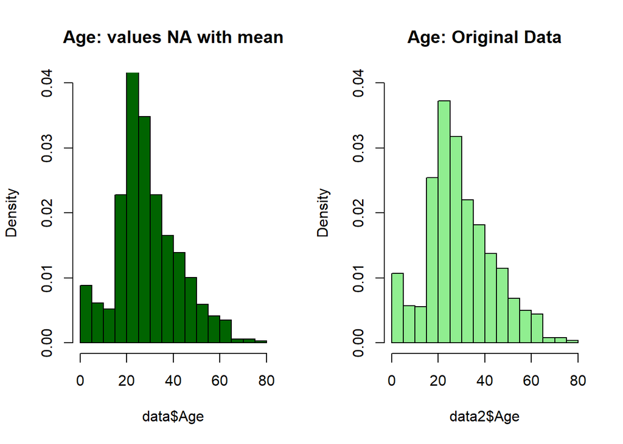

```r
data2<-rbind(data_train, data_test)
par(mfrow=c(1,2))
hist(data$Age, freq=F, main="Age: values NA with mean",col='darkgreen', ylim=c(0,0.04))
hist(data2$Age, freq=F, main="Age: Original Data",col='lightgreen', ylim=c(0,0.04))
```

Es pot observar que el fet de modificar els valors NA d’Age seguint el mètode de k-Nearest Neighbors no afecta gaire a la distribució dels valors, per tant es pot concluir que es una bona aproximació dels valors.

En el cas de l’atribut cabina (cabin) tenim 1014 registres buits dels 1309 del dataset. A més els valors que tenim estan molt fragmentats. En aquestes circumstancies l’atibut cabina no ens aportarà informació rellevant o fiable, així que l’eliminarem en la part de selecció d’atributs (apartat 4.1).

L’atribut tarifa (fare) conté un valor NA. En aquest cas el modifiquem i li posem la mitjana. Per a no pasarli un valor fixe, modifiquem la forma de assignar la mitjana al valor nul. Calculo la mitjana de la variable Fare, excloent al càlcul els valors NA.

```r
data$Fare[is.na(data$Fare)] <- mean(data$Fare, na.rm=TRUE)
```

### 3.2. Identificació i tractament de valors extrems.

Busquem valors extrems en els atributs númerics. Comencem amb un mètode molt visualt, el blotpox.

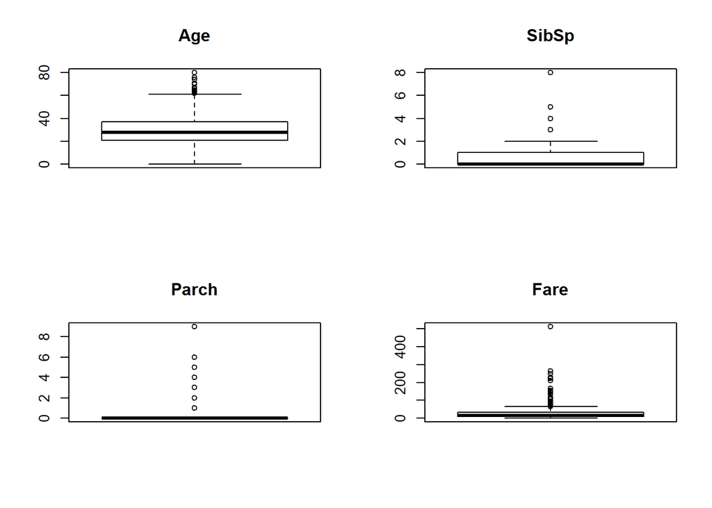

```r
par(mfrow=c(2,2))
for(i in 2:ncol(data)) #ignorem PassengerId
{
  if ((is.numeric(data[,i]))||(is.integer(data[,i])))
  {
    boxplot(data[,i], main = colnames(data)[i], width=100)
  }

}
```

```r
boxplot.stats(data$Age)$out
```

```
##  [1] 66.0 65.0 71.0 70.5 62.0 63.0 65.0 64.0 65.0 63.0 71.0 64.0 62.0 62.0
## [15] 80.0 70.0 70.0 62.0 74.0 62.0 63.0 67.0 76.0 63.0 64.0 64.0 64.0
```

```r
boxplot.stats(data$SibSp)$out
```

```
##  [1] 3 4 3 3 4 5 3 4 5 3 3 4 8 4 4 3 8 4 8 3 4 4 4 4 8 3 3 5 3 5 3 4 4 3 3
## [36] 5 4 3 4 8 4 3 4 8 4 8 3 4 5 3 4 8 4 8 4 3 3
```

```r
boxplot.stats(data$Parch)$out
```

```
##   [1] 1 2 1 5 1 1 5 2 2 1 1 2 2 2 1 2 2 2 3 2 2 1 1 1 1 2 1 1 2 2 1 2 2 2 1
##  [36] 2 1 1 2 1 4 1 1 1 1 2 2 1 2 1 1 1 2 1 1 2 2 2 1 1 2 2 1 2 1 1 1 1 1 1
##  [71] 1 2 1 2 2 1 1 2 1 1 2 1 1 1 1 2 1 1 1 4 1 1 2 2 2 2 2 1 1 1 2 2 1 1 2
## [106] 2 3 4 1 2 1 1 2 1 2 1 2 1 1 2 2 1 1 1 1 2 2 2 2 2 2 1 1 2 1 4 1 1 2 1
## [141] 2 1 1 2 5 2 1 1 1 2 1 5 2 1 1 1 2 1 6 1 2 1 2 1 1 1 1 1 1 1 3 2 1 1 1
## [176] 1 2 1 2 3 1 2 1 2 2 1 1 2 1 2 1 2 1 1 1 2 1 1 2 1 2 1 1 1 1 3 2 1 1 1
## [211] 1 5 2 1 1 1 1 3 1 2 2 1 2 1 2 1 2 4 1 1 2 1 1 1 4 6 2 3 1 1 2 2 2 1 1
## [246] 2 5 2 3 2 1 1 1 2 1 2 2 2 1 2 1 1 2 1 2 1 2 1 2 2 1 1 1 1 1 2 1 1 2 1
## [281] 1 1 2 1 2 9 1 1 1 2 2 2 1 9 1 1 2 2 1 1 2 1 1 1 1 1 1
```

```r
boxplot.stats(data$Fare)$out
```

```
##   [1]  71.2833 263.0000 146.5208  82.1708  76.7292  80.0000  83.4750
##   [8]  73.5000 263.0000  77.2875 247.5208  73.5000  77.2875  79.2000
##  [15]  66.6000  69.5500  69.5500 146.5208  69.5500 113.2750  76.2917
##  [22]  90.0000  83.4750  90.0000  79.2000  86.5000 512.3292  79.6500
##  [29] 153.4625 135.6333  77.9583  78.8500  91.0792 151.5500 247.5208
##  [36] 151.5500 110.8833 108.9000  83.1583 262.3750 164.8667 134.5000
##  [43]  69.5500 135.6333 153.4625 133.6500  66.6000 134.5000 263.0000
##  [50]  75.2500  69.3000 135.6333  82.1708 211.5000 227.5250  73.5000
##  [57] 120.0000 113.2750  90.0000 120.0000 263.0000  81.8583  89.1042
##  [64]  91.0792  90.0000  78.2667 151.5500  86.5000 108.9000  93.5000
##  [71] 221.7792 106.4250  71.0000 106.4250 110.8833 227.5250  79.6500
##  [78] 110.8833  79.6500  79.2000  78.2667 153.4625  77.9583  69.3000
##  [85]  76.7292  73.5000 113.2750 133.6500  73.5000 512.3292  76.7292
##  [92] 211.3375 110.8833 227.5250 151.5500 227.5250 211.3375 512.3292
##  [99]  78.8500 262.3750  71.0000  86.5000 120.0000  77.9583 211.3375
## [106]  79.2000  69.5500 120.0000  93.5000  80.0000  83.1583  69.5500
## [113]  89.1042 164.8667  69.5500  83.1583  82.2667 262.3750  76.2917
## [120] 263.0000 262.3750 262.3750 263.0000 211.5000 211.5000 221.7792
## [127]  78.8500 221.7792  75.2417 151.5500 262.3750  83.1583 221.7792
## [134]  83.1583  83.1583 247.5208  69.5500 134.5000 227.5250  73.5000
## [141] 164.8667 211.5000  71.2833  75.2500 106.4250 134.5000 136.7792
## [148]  75.2417 136.7792  82.2667  81.8583 151.5500  93.5000 135.6333
## [155] 146.5208 211.3375  79.2000  69.5500 512.3292  73.5000  69.5500
## [162]  69.5500 134.5000  81.8583 262.3750  93.5000  79.2000 164.8667
## [169] 211.5000  90.0000 108.9000
```

Els valors dels outliers mostrar pel boxplot de l’atribut edat són valors coherents, no els considerem outliers, ja que es mostren forà del gràfic per la concentració de valors entre els 20 i 30 anys.

El mateix es pot dir pels atributs SibSp i Parch, la majoria de regsitres tenen valor 0, i fa que el boxplot estigui molt comprimit en aquest interval. Tenir 8 fills és un valor elevat, pero no es pot considerar irreal.

En el cas de l’atribut Fare revisarem a continuació amb més detall els seus valors depenent de l’atribut Pclass, que clarament està relacionat.

```r
par(mfrow=c(2,2))
boxplot(data$Fare[data$Pclass==1], main = "Fare - Pclass=1", width=100)
boxplot(data$Fare[data$Pclass==2], main = "Fare - Pclass=2", width=100)
boxplot(data$Fare[data$Pclass==3], main = "Fare - Pclass=3", width=100)

summary(data$Fare[data$Pclass==1])
```

```
##    Min. 1st Qu.  Median    Mean 3rd Qu.    Max.
##    0.00   30.70   60.00   87.51  107.66  512.33
```

```r
summary(data$Fare[data$Pclass==2])
```

```
##    Min. 1st Qu.  Median    Mean 3rd Qu.    Max.
##    0.00   13.00   15.05   21.18   26.00   73.50
```

```r
summary(data$Fare[data$Pclass==3])
```

```
##    Min. 1st Qu.  Median    Mean 3rd Qu.    Max.
##    0.00    7.75    8.05   13.33   15.25   69.55
```

[figure not shown]

Un cop analitzat la tarifa dels bitllets de les diferents classes, observant els valors mitjans, es pot observar una diferència raonable en els preus dels bitllets entre les diferents classes, sent més alta la tarifa a primera classe i més baixa a tercera. Tot i això, sobretot a tercera classe, s’observen uns preus extrems, que podríem considerar erronis, però degut a que no disposem de més informació, decidirem no tractar amb aquests valors, degut a que podría ser correcta aquesta informació.

### 4.1. Selecció dels grups de dades que es volen analitzar/comparar (planificació dels anàlisis a aplicar).

Com ja hem comentat anteriorment, tenim atributs que no aporten cap informació útil (PassengerId, Name), i d’altres que tenen masses registres buits perquè puguin aportar informació valida (Cabin). Els eliminem.

```r
data<-data[ , -which(names(data) %in% c("PassengerId","Name","Cabin"))]
```

Es vol comparar quins pesos tenen els diferents atributs sobre la supervivenvia o no d’un individu, quins són els factors que més influeixen.

### 4.2. Comprovació de la normalitat i homogeneïtat de la variància.

Per comprobar la normailitat de les dades fem servir un anàlisi visual (qqplot i histograma) i el test shapiro-wilk.

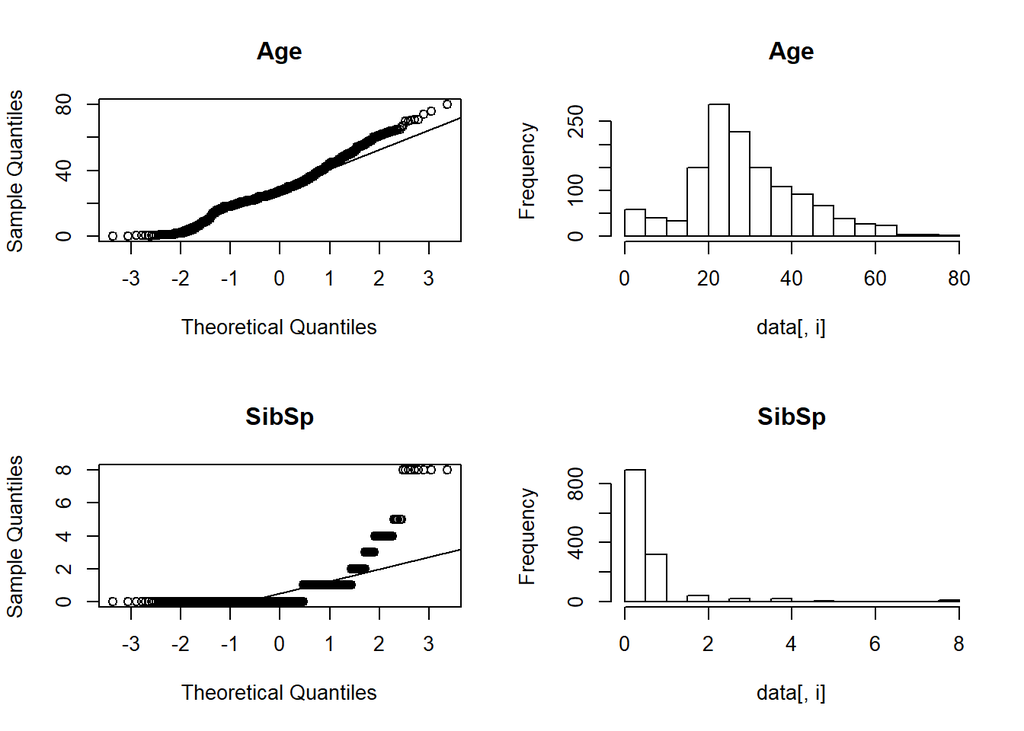

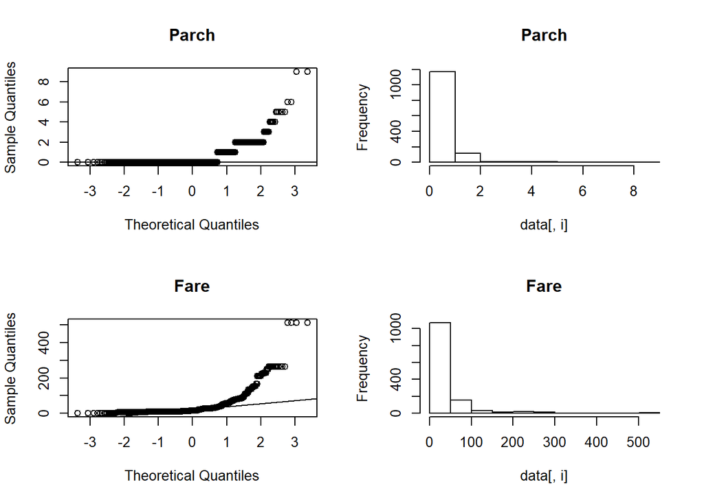

```r
par(mfrow=c(2,2))
for(i in 1:ncol(data))
{
  if ((is.numeric(data[,i]))|(is.integer(data[,i])))
  {
    qqnorm(data[,i], main = colnames(data)[i]);qqline(data[,i])
    hist(data[,i], main = colnames(data)[i])
  }
}
```

Apliquem l’algoritme de shapiro-wilk.

```r
shapiro.test(data$Age)
```

```
##
##  Shapiro-Wilk normality test
##
## data:  data$Age
## W = 0.97428, p-value = 1.608e-14
```

```r
shapiro.test(data$SibSp)
```

```
##
##  Shapiro-Wilk normality test
##
## data:  data$SibSp
## W = 0.51108, p-value < 2.2e-16
```

```r
shapiro.test(data$Parch)
```

```
##
##  Shapiro-Wilk normality test
##
## data:  data$Parch
## W = 0.49797, p-value < 2.2e-16
```

```r
shapiro.test(data$Fare)
```

```
##
##  Shapiro-Wilk normality test
##
## data:  data$Fare
## W = 0.52786, p-value < 2.2e-16
```

Els tests de shapiro-wilk ens retornen un p-valor inferior a 0.05 per tant no es compleix la hipòtesis nul·la i per tant les dades no segueixen una distribució normal.

Tant els gràfics com el test de shapiro-wilk, ens indiquen que les dades no segueixen una distribució normal. Però sabem pel que diu el teorema del límit central, que si tenim més de 30 distribucions, es pot aproximar a una distribució normal de mitja 0 i desviació estàndard 1.

### 4.3. Aplicació de proves estadístiques per comparar els grups de dades. En funció de les dades i de l’objectiu de l’estudi, aplicar proves de contrast d’hipòtesis, correlacions, regressions, etc. Aplicar almenys tres mètodes d’anàlisi diferents.

#### Model d’arbre de classificació

El primer model creat, per a predir si un passatger sobreviu o no, serà un model d’arbre de classificació. El primer pas es generar el conjunt d’entrenament, amb el qual es crearà el model, i el conjunt de test, amb el qual es comprobarà com de bo es el model.

```r
train<-data[1:891,]
test<-data[892:1309,]

library(C50)
vars<-c("Pclass","Sex","Age","SibSp","Parch","Fare")
str(data[c(vars,"Survived")])
```

```
## 'data.frame':    1309 obs. of  7 variables:
##  $ Pclass  : Factor w/ 3 levels "1","2","3": 3 1 3 1 3 3 1 3 3 2 ...
##  $ Sex     : Factor w/ 2 levels "female","male": 2 1 1 1 2 2 2 2 1 1 ...
##  $ Age     : num  22 38 26 35 35 20 54 2 27 14 ...
##  $ SibSp   : int  1 1 0 1 0 0 0 3 0 1 ...
##  $ Parch   : int  0 0 0 0 0 0 0 1 2 0 ...
##  $ Fare    : num  7.25 71.28 7.92 53.1 8.05 ...
##  $ Survived: logi  FALSE TRUE TRUE TRUE FALSE FALSE ...
```

```r
train$Survived<-as.factor(train$Survived)
tree_mod <-C5.0(x=train[,vars],y=train$Survived)
```

A continuació es mostra el model d’arbre de classificació generat.

```r
summary(tree_mod)
```

```
##
## Call:
## C5.0.default(x = train[, vars], y = train$Survived)
##
##
## C5.0 [Release 2.07 GPL Edition]      Sat May 25 17:35:47 2019
## -------------------------------
##
## Class specified by attribute `outcome'
##
## Read 891 cases (7 attributes) from undefined.data
##
## Decision tree:
##
## Sex = female:
## :...Pclass in {1,2}: TRUE (170/9)
## :   Pclass = 3:
## :   :...Fare <= 23.25: TRUE (117/48)
## :       Fare > 23.25: FALSE (27/3)
## Sex = male:
## :...Age > 9: FALSE (542/88)
##     Age <= 9:
##     :...SibSp <= 2: TRUE (20)
##         SibSp > 2: FALSE (15/1)
##
##
## Evaluation on training data (891 cases):
##
##      Decision Tree
##    ----------------
##    Size      Errors
##
##       6  149(16.7%)   <<
##
##
##     (a)   (b)    <-classified as
##    ----  ----
##     492    57    (a): class FALSE
##      92   250    (b): class TRUE
##
##
##  Attribute usage:
##
##  100.00% Sex
##   64.76% Age
##   35.24% Pclass
##   16.16% Fare
##    3.93% SibSp
##
##
## Time: 0.0 secs
```

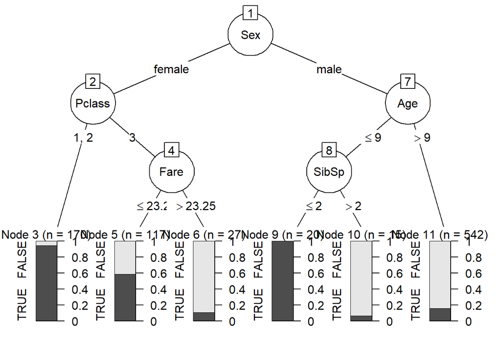

```r
plot(tree_mod)
```

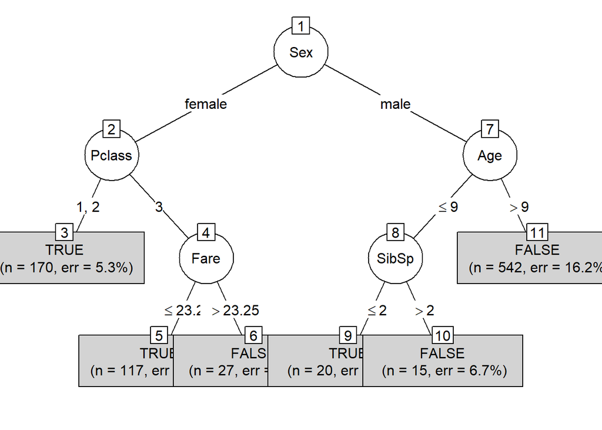

```r
plot(tree_mod,type="simple")
```

Un cop generat el model, es vol comprobar que el model funciona correctament. Per això, utilitzem el conjunt de test per a comprobar com de bo es el model.

```r
p1<-predict(tree_mod,test)
summary(p1)
```

```
## FALSE  TRUE
##   260   158
```

```r
table(test$Survived,Predicted=p1)
```

```
##        Predicted
##         FALSE TRUE
##   FALSE   254   12
##   TRUE      6  146
```

#### Model de regressió múltiple

Ara utilitzarem mètodes de regressió múltiple per esbrinar quins són els atributs que tenen un pes més significatiu en la supervivencia d’una persona.

```r
#train<-data[1:891,]
#test<-data[892:1309,]
modelA<-lm(data$Survived ~ data$Sex + data$Age)
modelB<-lm(data$Survived ~ data$Sex + data$Age + data$Pclass)
modelC<-lm(data$Survived ~ data$Sex + data$Age + data$Pclass + data$SibSp)
modelD<-lm(data$Survived ~ data$Sex + data$Age + data$Pclass + data$SibSp + data$Embarked)
modelE<-lm(data$Survived ~ data$Sex + data$Age + data$Pclass + data$SibSp + data$Embarked + data$Fare)
modelF<-lm(data$Survived ~ data$Sex + data$Age + data$Pclass + data$SibSp + data$Embarked + data$Fare + data$Parch)

taulaReg<-matrix(c('A',summary(modelA)$r.squared,
                    'B',summary(modelB)$r.squared,
                    'C',summary(modelC)$r.squared,
                    'D',summary(modelD)$r.squared,
                    'E',summary(modelE)$r.squared,
                    'F',summary(modelF)$r.squared), ncol=2, byrow = TRUE)

colnames(taulaReg)<-c("Model","R^2")
taulaReg
```

```
##      Model R^2
## [1,] "A"   "0.474094399990495"
## [2,] "B"   "0.511724878814509"
## [3,] "C"   "0.51837487026375"
## [4,] "D"   "0.519476548157216"
## [5,] "E"   "0.519800159890929"
## [6,] "F"   "0.519978379885903"
```

Els resultats obtinguts no són especialment bons, el millor dels models el F, només explica el 52% dels casos totals, pero la diferencia del model f amb el C és infima, donat que els nous atributs introduits no són significatius. De totes maneres ens es útil per veure com influeixen els atributs en la supervivencia.

```r
summary(modelF)
```

```
##
## Call:
## lm(formula = data$Survived ~ data$Sex + data$Age + data$Pclass +
##     data$SibSp + data$Embarked + data$Fare + data$Parch)
##
## Residuals:
##      Min       1Q   Median       3Q      Max
## -1.05726 -0.14010 -0.05733  0.14778  1.00113
##
## Coefficients:
##                  Estimate Std. Error t value Pr(>|t|)
## (Intercept)     1.1047254  0.0463862  23.816  < 2e-16 ***
## data$Sexmale   -0.6676618  0.0205352 -32.513  < 2e-16 ***
## data$Age       -0.0037789  0.0008020  -4.712 2.72e-06 ***
## data$Pclass2   -0.1252356  0.0335836  -3.729 0.000200 ***
## data$Pclass3   -0.2426470  0.0323425  -7.502 1.16e-13 ***
## data$SibSp     -0.0378592  0.0100595  -3.764 0.000175 ***
## data$EmbarkedQ  0.0225065  0.0392975   0.573 0.566933
## data$EmbarkedS -0.0238933  0.0249661  -0.957 0.338729
## data$Fare       0.0002557  0.0002414   1.059 0.289699
## data$Parch     -0.0084539  0.0121732  -0.694 0.487513
## ---
## Signif. codes:  0 '***' 0.001 '**' 0.01 '*' 0.05 '.' 0.1 ' ' 1
##
## Residual standard error: 0.3371 on 1299 degrees of freedom
## Multiple R-squared:   0.52,  Adjusted R-squared:  0.5167
## F-statistic: 156.3 on 9 and 1299 DF,  p-value: < 2.2e-16
```

Podem veure com els atributs més significatius són el sex, age, Pclass i SibSp. El mòdel ens indica que si el sexe = home les probabilitats de supervivencia cauen de manera significativa, al igual que si esten en segona classe o especialment en la tercera.

En canvi els atributs Embarked, Fare i Parch són poc significatius a l’hora d’explicar la supervivencia.

```r
pred<-predict(modelF)

table(data$Survived,pred>0.5)
```

```
##
##         FALSE TRUE
##   FALSE   737   78
##   TRUE    110  384
```

Depenent del umbral de tall obtindrem més falsos positius o falsos negatius, de totes maneres amb el model obtingut, el nivell d’errors él bastant alt.

#### Model de classificació Bayesià

Per últim es decideix generar un segon model de classificació, però aquest cop seguint un classificador Bayesià ingenu, mitjançant NaiveBayes. NaiveBayes es un algoritme d’aprenentatge automàtic basat en el teorema de Bayes.

El primer pas es establir quines variables s’utilitzaràn per a generar el model. Desprès de diverses probes, s’ha vist que, el·liminant les variables Parch, Ticket, Fare y Embarked, s’aconsegueix el model més exacte. Per tant, el primer punt es el·liminar aquestes variables. Això permet assegurar que els resultats del model de regressió múltiple anterior son correctes, ja que amb les variables més rellevants que s’indiquen al model anterior, es quan s’aconsegueix el millor model de predicció.

```r
dataNaiveBayes <- data

dataNaiveBayes <- within(dataNaiveBayes,{
      Parch <- NULL
      Ticket <- NULL
      Fare <- NULL
      Embarked <- NULL
  })
trainNaiveBayes<-dataNaiveBayes[1:891,]
testNaiveBayes<-dataNaiveBayes[892:1309,]
```

El model generat es el següent.

```r
model <- naiveBayes(Survived ~ ., data = trainNaiveBayes)
model
```

```
##
## Naive Bayes Classifier for Discrete Predictors
##
## Call:
## naiveBayes.default(x = X, y = Y, laplace = laplace)
##
## A-priori probabilities:
## Y
##     FALSE      TRUE
## 0.6161616 0.3838384
##
## Conditional probabilities:
##        Pclass
## Y               1         2         3
##   FALSE 0.1457195 0.1766849 0.6775956
##   TRUE  0.3976608 0.2543860 0.3479532
##
##        Sex
## Y          female      male
##   FALSE 0.1475410 0.8524590
##   TRUE  0.6812865 0.3187135
##
##        Age
## Y           [,1]     [,2]
##   FALSE 29.89435 13.30605
##   TRUE  28.73003 14.34411
##
##        SibSp
## Y            [,1]      [,2]
##   FALSE 0.5537341 1.2883991
##   TRUE  0.4736842 0.7086875
```

Un cop generat el model, es proba el model amb el conjunt de test.

```r
pred <- predict(model,testNaiveBayes)
tab <- table(testNaiveBayes$Survived, pred, dnn=c("Actual", "Predita"))
confusionMatrix(tab)
```

```
## Confusion Matrix and Statistics
##
##        Predita
## Actual  FALSE TRUE
##   FALSE   258    8
##   TRUE      6  146
##
##                Accuracy : 0.9665
##                  95% CI : (0.9444, 0.9816)
##     No Information Rate : 0.6316
##     P-Value [Acc > NIR] : <2e-16
##
##                   Kappa : 0.9278
##
##  Mcnemar's Test P-Value : 0.7893
##
##             Sensitivity : 0.9773
##             Specificity : 0.9481
##          Pos Pred Value : 0.9699
##          Neg Pred Value : 0.9605
##              Prevalence : 0.6316
##          Detection Rate : 0.6172
##    Detection Prevalence : 0.6364
##       Balanced Accuracy : 0.9627
##
##        'Positive' Class : FALSE
##
```

Un cop probat el model amb el conjunt de test, es pot observar que aquest es més acurat que el model d’arbre de classificació anterior a l’hora de predir si un passatger sobreviu o no.

### Resolució del problema.A partir dels resultats obtinguts, quines són les conclusions? Els resultats permeten respondre al problema?

Un cop realitzat tot l’anàlisi, es pot assegurar que les variables necessàries per a predir si un passatger sobreviu o no són: Sex, Age, Pclass i SibSp

Generant un model amb aquestes dades som capaços de predir, amb una exactitud del 96,65%, si un passatger sobreviu o no, utilitzant únicament les dades esmentades.

Per tant, com a conclusió, podem dir que s’ha aconseguit respondre a les preguntes inicials, que era estudiar quines variables tenen més impacte en la taxa de supervivència dels passatgers i, mitjançant aquestes, generar un model adequat per a predir qualsevol altre cas possible.